# Practical Machine Learning Final Project

Anthony Del Signore

12/28/2019

The complied data, which acts as the source for this analysis, contains quantified indicators of how well several participants performed multiple exercises. Much of the data was compiled using several fitness devices. Each participant was asked to perform barbell lifts correctly and incorrectly five different ways, as indicated by the “classe” variable. The goal of this project is to predict “classe” using other variables contained within the datasets.

This analysis examines the following questions: 1) How I built the model. Specifically, what algorithm is best suited to predict, accurately, classe on a set of 20 test cases. 2) How I used cross-validation techniques. 3) Ascertain expected out of sample error.

Also, I provide some insight at moments to show my thought process behind the choices I made.

Finally, I provide a figure in the appendix for consideration.

**Loading Packages, Loading Data, and Cleaning**

The first step is to load the following packages. Through the four weeks of this course, I believe these packages would be the most helpful for my analysis.

```r
library(caret); library(rpart); library(rpart.plot); library(rattle); library(randomForest);library(e1071); library(ggplot2)
```

I set the seed for future replication, though it is beyond the scope of this assignment.

```r
set.seed(100)
```

Next I loaded the training data and removed several columns from consideration. At first, I left all of the columns in my analysis. However, an error kept occurring which said the date format on two of the variables was incorrect.

```r
#Read training data and change all NAs to NA strings
dat <- read.csv("/Users/delsiaj/Desktop/Data Science Course/pml-training.csv", na.strings=c("NA","#DIV/0!",""))
dat1 <- dat[,8:length(colnames(dat))]

#Remove NAs
dat_clean <- dat1[, colSums(is.na(dat1)) == 0]
```

**Training the Data and Exploratory Analysis** Next, I trained the data as shown below and sliced it into cross-validation sets.

```r
#Create data partitions
inTrain <- createDataPartition(dat_clean$classe, p=0.7, list=FALSE)

training <- dat_clean[inTrain, ]; testing <- dat_clean[-inTrain,]
dim(training); dim(testing)
```

```
## [1] 13737    53
```

```
## [1] 5885   53
```

```r
#Defining and Training the Model

model1 <- train(classe ~ ., data=training, method="rf", trControl = trainControl(method="cv"), number=5)

model1
```

```
## Random Forest
##
## 13737 samples
##    52 predictor
##     5 classes: 'A', 'B', 'C', 'D', 'E'
##
## No pre-processing
## Resampling: Cross-Validated (10 fold)
## Summary of sample sizes: 12363, 12364, 12364, 12363, 12363, 12364, ...
## Resampling results across tuning parameters:
##
##   mtry  Accuracy   Kappa
##    2    0.9911915  0.9888565
##   27    0.9914826  0.9892252
##   52    0.9820921  0.9773439
##
## Accuracy was used to select the optimal model using the largest value.
## The final value used for the model was mtry = 27.
```

**Predictions** Next, I test the model’s performance on the training data against that of the validation set.

```r
#Predictions
model_pred <- predict(model1, testing)
confusionMatrix(testing$classe, model_pred)
```

```
## Confusion Matrix and Statistics
##
##           Reference
## Prediction    A    B    C    D    E
##          A 1672    2    0    0    0
##          B    7 1132    0    0    0
##          C    0    4 1021    1    0
##          D    0    0   12  952    0
##          E    0    0    2    1 1079
##
## Overall Statistics
##
##                Accuracy : 0.9951
##                  95% CI : (0.9929, 0.9967)
##     No Information Rate : 0.2853
##     P-Value [Acc > NIR] : < 2.2e-16
##
##                   Kappa : 0.9938
##
##  Mcnemar's Test P-Value : NA
##
## Statistics by Class:
##
##                      Class: A Class: B Class: C Class: D Class: E
## Sensitivity            0.9958   0.9947   0.9865   0.9979   1.0000
## Specificity            0.9995   0.9985   0.9990   0.9976   0.9994
## Pos Pred Value         0.9988   0.9939   0.9951   0.9876   0.9972
## Neg Pred Value         0.9983   0.9987   0.9971   0.9996   1.0000
## Prevalence             0.2853   0.1934   0.1759   0.1621   0.1833
## Detection Rate         0.2841   0.1924   0.1735   0.1618   0.1833
## Detection Prevalence   0.2845   0.1935   0.1743   0.1638   0.1839
## Balanced Accuracy      0.9977   0.9966   0.9927   0.9977   0.9997
```

```r
#Overall Accuracy and Out of Sample Error
acc <- postResample(model_pred, testing$classe)
acc1 <- acc[1]

sample_error <- 1 - as.numeric(confusionMatrix(testing$classe, model_pred)$overall[1])

acc1
```

```
##  Accuracy
## 0.9950722
```

```r
sample_error
```

```
## [1] 0.004927782
```

These predictions help determine accuracy and out-of-sample error.

**Application to Test Data** Finally, the model is used on the test data to predict the classe of each of the 20 observations.

```r
#Apply to the test CSV
dat_test <- read.csv("/Users/delsiaj/Desktop/Data Science Course/pml-testing.csv", na.strings=c("NA","#DIV/0!",""))
dat_test_clean <- dat_test[, colSums(is.na(dat_test)) == 0]
dat_test_clean1 <- dat_test_clean[,8:length(colnames(dat_test_clean))]

test_pred <- predict(model1,dat_test_clean1[, -length(names(dat_test_clean1))])

test_pred
```

```
##  [1] B A B A A E D B A A B C B A E E A B B B
## Levels: A B C D E
```

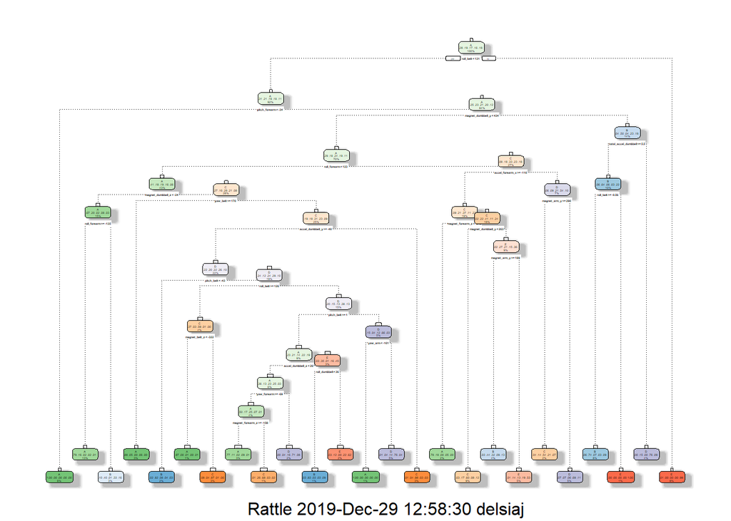

```r
#Tree Visualization
library(rpart.plot)
tree <- rpart(classe ~ ., data=training, method="class", maxdepth=15)
fancyRpartPlot(tree)
```